# PresentationIntroductionR

## Aufgabe1 Einführung in R mit W3 school

## Basic Synatax of R

For print statements in R, use single or double quotes. For simple calculations just write out the equation.

```r
"Hello World"
```

```
## [1] "Hello World"
```

```r
5 + 5
```

```
## [1] 10
```

For comments just write a # in front of the statement, there is no possibility for multiline comments with just one declaration.

For assigning variables you use variable <- value, there is no need to declare the data type. For printing out variables its enough to just write their names, although there is also the possibility to use the print() function.

```r
name <- "Nick"
age <- 21
name
```

```
## [1] "Nick"
```

```r
age
```

```
## [1] 21
```

Data Types in R are quite similar to other programming languages, the declaration is a bit different and its more math based. The datatype can be displayed with class().Important: Integers are signed/ marked with an L after the value, and complex numbers are written with a imaginary and real part. Basic Data Types are:

```r
#numeric
x <- 15.0
class(x)
```

```
## [1] "numeric"
```

```r
#integer
x <- 100L
class(x)
```

```
## [1] "integer"
```

```r
#complex
x <- 9i + 3
class(x)
```

```
## [1] "complex"
```

```r
#character/ string
x <- "This is cool"
class(x)
```

```
## [1] "character"
```

```r
#boolean
x <- TRUE
class(x)
```

```
## [1] "logical"
```

## Basic Math Functions

The min(), max() function, shows the highest / lowest number of its input, the sqrt() function returns the square root of a number, The abs() function returns the positive value of a number:

```r
max(5, 6, 7)
```

```
## [1] 7
```

```r
sqrt(4)
```

```
## [1] 2
```

```r
abs(-5)
```

```
## [1] 5
```

Booleans, when comparing two values the expression is evaluated to an boolean:

```r
10 > 9
```

```
## [1] TRUE
```

```r
10 == 9 #equals
```

```
## [1] FALSE
```

```r
10 < 9
```

```
## [1] FALSE
```

```r
# its also possible to write if statements:
a <- 10
b <-9
if (b > a){
  "b is greater than a"
}else{"b is not greater than a"}
```

```
## [1] "b is not greater than a"
```

## Loops

The Loops in R are quite similar to Java, we use the same curly brackets and similar syntax: While Loop:

```r
i <- 0
while (i < 6) {
  i <- i + 1
  if (i == 3) {
    next
  }
  print(i)
}
```

```
## [1] 1
## [1] 2
## [1] 4
## [1] 5
## [1] 6
```

For Loop:

```r
for (x in 1:10) {
  print(x)
}
```

```
## [1] 1
## [1] 2
## [1] 3
## [1] 4
## [1] 5
## [1] 6
## [1] 7
## [1] 8
## [1] 9
## [1] 10
```

With the break statement, we can stop the loop before it has looped through all the items. With the next statement, we can skip an iteration without terminating the loop. ## Functions Creating a Function in R, you assign to a variable the function keyword, you call it with the name and normal brackets: function_name <- function(Arguments){ what happens } function_name() calls the function To save the result of the function in a variable, you assign the function to the variable using the assignment Operator

```r
calculate_dice_vol <- function(length, width, height){
  volume <- length * width * height
  return(volume)
}

calculate_dice_vol(0.8, 1.6, 2.0)
```

```
## [1] 2.56
```

```r
dice_vol <- calculate_dice_vol(0.8, 1.6, 2.0)
```

R uses lexical scoping, the last evaluated expression is returned implicitly, and default parameters are defined in the signature.

print() statement: R automatically prints the result of the very last lane in a code chunk. If you have multiple function calls, the only the last one will appear in the document in a report. By wrapping the calls in print(), every result of the code chunk will be displayed in the report

```r
my_function <- function(x){
    return(5*x)
}

print(my_function(2))
```

```
## [1] 10
```

```r
print(my_function(4))
```

```
## [1] 20
```

```r
print(my_function(7))
```

```
## [1] 35
```

## The Apply Family

The apply family in R is a set of functions that replaces explicit loops by applying a function to each element of a data structure, making code shorter and more readable. Each member of the family targets a different input shape and returns a different output type, so choosing the right one depends on what you’re iterating over and what form you need the result in.

Apply Input: matrix/array Output: vector/list

```r
m <- matrix(1:12, nrow = 3)
apply(m, 1, sum)
```

```
## [1] 22 26 30
```

Lapply Input: list/vectors Output: list

```r
# lapply — get the mean of each list element, returns a list
lapply(list(a = 1:3, b = 4:6), mean)
```

```
## $a
## [1] 2
##
## $b
## [1] 5
```

Sapply Input: list/vector Output: vector/matrix

```r
# sapply — same as lapply but returns a simple vector
sapply(list(a = 1:3, b = 4:6), mean)
```

```
## a b
## 2 5
```

Tapply Input: vector + groups Output: array

```r
# tapply — mean score grouped by category
scores <- c(85, 90, 78, 92, 88)
groups <- c("A", "B", "A", "B", "A")
tapply(scores, groups, mean)
```

```
##        A        B
## 83.66667 91.00000
```

Mapply Input: multiple vectors Output: vector/list

```r
# mapply — raise each x to the power of the matching y
mapply(function(x, y) x^y, x = 1:4, y = 4:1)
```

```
## [1] 1 8 9 4
```

## Casting

In R, the numeric type is the default for numbers and refers to double-precision floating point, integer is separate and more memory efficient. Its created using the L suffix.

```r
# numeric in R is the general floating-point type (double by default)
x <- 3.14
class(x)      # "numeric"
```

```
## [1] "numeric"
```

```r
typeof(x)     # "double"
```

```
## [1] "double"
```

```r
y <- 3L       # the L suffix makes it an integer
typeof(y)     # "integer"
```

```
## [1] "integer"
```

```r
class(y)      # "integer"
```

```
## [1] "integer"
```

Casting means explicitly converting a value from one type to another

```r
as.integer(3.9)   #  3  (truncates, does NOT round)
```

```
## [1] 3
```

```r
as.double(3L)     #  3.0
```

```
## [1] 3
```

```r
as.character(42)  #  "42"
```

```
## [1] "42"
```

```r
as.numeric("3.5") #  3.5
```

```
## [1] 3.5
```

```r
as.numeric("abc") #  NA with a warning
```

```
## [1] NA
```

```r
# Implicit coercion in vectors (everything becomes the "widest" type)
c(1L, 2.5)        #  numeric (double)
```

```
## [1] 1.0 2.5
```

```r
c(1, "a")         #  character — everything becomes string!
```

```
## [1] "1" "a"
```

```r
c(TRUE, 1L, 2.5)  #  numeric: TRUE→1, FALSE→0
```

```
## [1] 1.0 1.0 2.5
```

## Factors in R

Factors in R are used to represent categorical data, storing values as integers internally while displaying them as meaningful labels. Unlike plain strings, factors have a fixed set of allowed values called levels, which makes them ideal for variables like survey answers or groups.

```r
sizes <- factor(c("small", "large", "medium", "small", "large"))
levels(sizes)    #  "large" "medium" "small"
```

```
## [1] "large"  "medium" "small"
```

```r
table(sizes)     # counts per category
```

```
## sizes
##  large medium  small
##      2      1      2
```

## Plotting in R

R comes with a built in plot() function that covers the most common chart types without needing any extra library. The most frequently used types are scatter plots, line plots, bar charts, histograms, and box plots, all controllable through simple parameters like main, col, and xlab. Scatter plot:

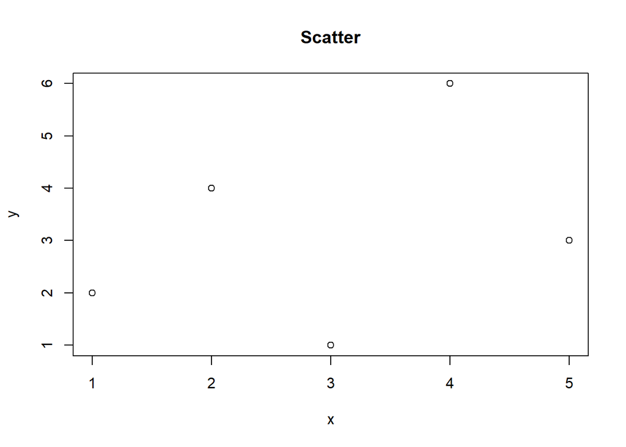

```r
plot(c(1,2,3,4,5), c(2,4,1,6,3), main = "Scatter", xlab = "x", ylab = "y")
```

Bar chart:

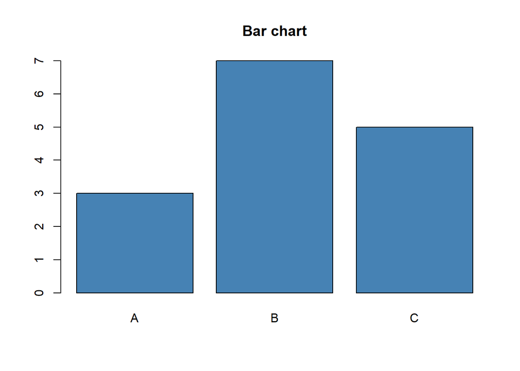

```r
barplot(c(A=3, B=7, C=5), col = "steelblue", main = "Bar chart")
```

Histogram:

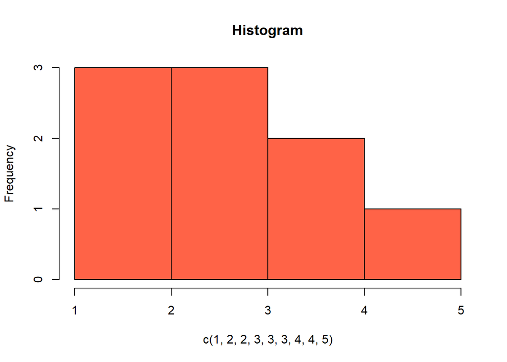

```r
# histogram
hist(c(1,2,2,3,3,3,4,4,5), main = "Histogram", col = "tomato")
```

Box plot:

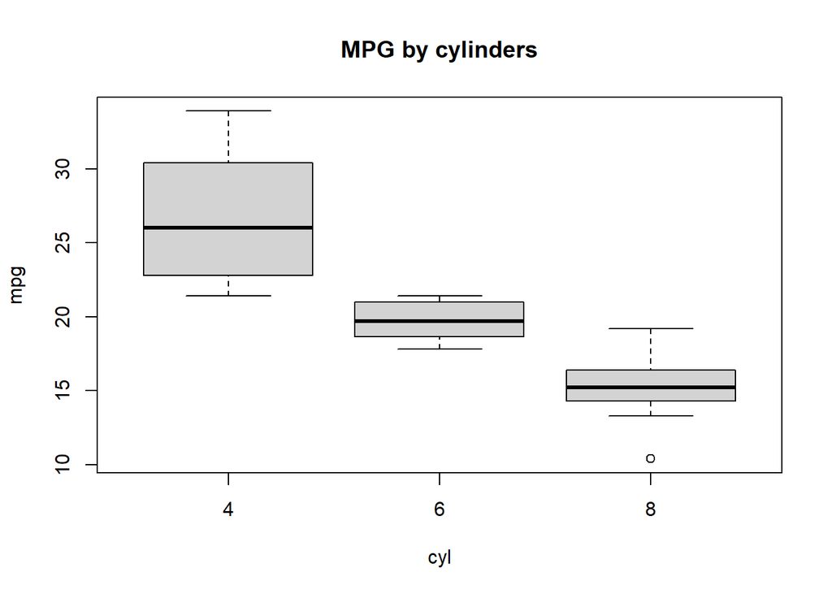

```r
# box plot
boxplot(mpg ~ cyl, data = mtcars, main = "MPG by cylinders")
```

## Task 2: Expression data

Read in the csv file and have a look at it with head and str. To be sure, acitvating the path-finding tool with library(here) may help to prevent issues in finding the file.

```r
library(here)
```

```r
data <- read.csv(here("basic_yeast_heatshock.csv"))
head(data)
```

```
##    gene_id X25_0_r1 X25_0_r2 X25_0_r3 X42_10_r1 X42_10_r2 X42_10_r3 X42_30_r1
## 1 15S_rRNA        2        0        5         0         2         0         1
## 2 21S_rRNA       79       18       33        50        11        12        27
## 3     HRA1        0        0        1         5         2         4         3
## 4     ICR1      105      154      215       208       159       162       297
## 5     LSR1       51        8        9         8        12        12        39
## 6     NME1       23       10       15       172        43        74       104
##   X42_30_r2 X42_30_r3
## 1         2         1
## 2        67        33
## 3         5         8
## 4       495       418
## 5        43        58
## 6       188       161
```

```r
str(data)
```

```
## 'data.frame':    7126 obs. of  10 variables:
##  $ gene_id  : chr  "15S_rRNA" "21S_rRNA" "HRA1" "ICR1" ...
##  $ X25_0_r1 : int  2 79 0 105 51 23 2 0 0 0 ...
##  $ X25_0_r2 : int  0 18 0 154 8 10 0 0 0 0 ...
##  $ X25_0_r3 : int  5 33 1 215 9 15 1 0 0 0 ...
##  $ X42_10_r1: int  0 50 5 208 8 172 54 0 0 0 ...
##  $ X42_10_r2: int  2 11 2 159 12 43 13 0 0 0 ...
##  $ X42_10_r3: int  0 12 4 162 12 74 21 0 0 0 ...
##  $ X42_30_r1: int  1 27 3 297 39 104 31 0 0 0 ...
##  $ X42_30_r2: int  2 67 5 495 43 188 31 0 0 0 ...
##  $ X42_30_r3: int  1 33 8 418 58 161 30 0 0 0 ...
```

### Histograms 3x3 grid

Plotting the first sample column to check, if everything works correctly and looks appropriate. In a histogram, the expression ca be briefly summarized. par() -> determine graphical parameters mfrow -> “Multi-Frame by row” (creates a grid) c(3, 3) -> 3 rows and 3 columns in the grid log2 Transformation to see the distribution comfortable R automatically prepends an ‘X’ to the column headers because variable names in R cannot begin with a numerical character.

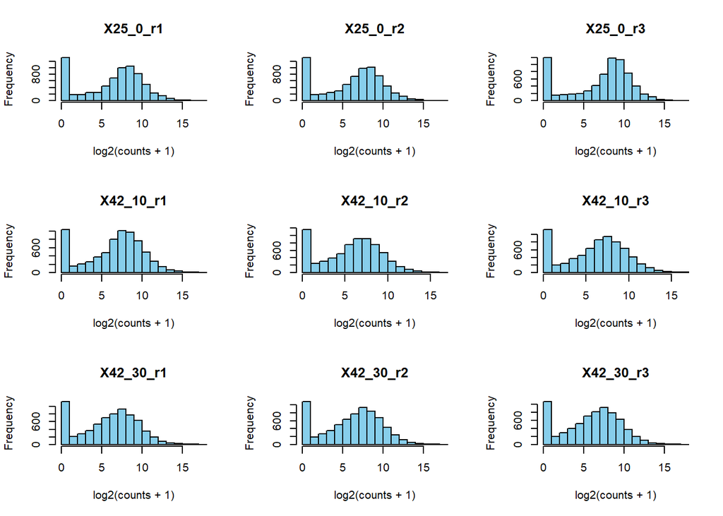

```r
# Set up a 3x3 grid
par(mfrow = c(3, 3))

#Using a loop to plot the columns 2 to 10 (1 is gen_id), to only write the code once and #make it lucid
for(i in 2:10){
  hist(log2(data[, i] + 1),
       main = colnames(data)[i],
       xlab = "log2(counts + 1)",
       col = "skyblue")
}
```

```r
par(mfrow = c(1, 1))
```

### Calculate the quantiles to describe the distribution numerically

```r
results <- matrix(ncol = 6, nrow = 9)
colnames(results) <- c("Sample", "Q5", "Q25", "Q50", "Q75", "Q95")
for(i in 2:10){
  vals <- round(quantile(log2(data[, i] + 1), probs = c(0.05, 0.25, 0.5, 0.75, 0.95)), 2)
  results[i-1, 1] <- colnames(data)[i]
  results[i-1, 2:6] <- vals
}
results_df <- as.data.frame(results)
print(results_df)
```

```
##      Sample Q5  Q25  Q50  Q75   Q95
## 1  X25_0_r1  0 3.58 7.33 9.01 11.43
## 2  X25_0_r2  0 3.46 7.11 8.87 11.35
## 3  X25_0_r3  0 4.52 8.26 9.75 11.95
## 4 X42_10_r1  0 4.39 7.25 9.03 11.58
## 5 X42_10_r2  0 3.32 6.21 8.17 10.87
## 6 X42_10_r3  0  3.7 6.66 8.62 11.41
## 7 X42_30_r1  0 3.58 6.48 8.43 11.12
## 8 X42_30_r2  0 3.81 6.71 8.72 11.32
## 9 X42_30_r3  0 3.58 6.49  8.5 11.15
```

```r
knitr::kable(results_df)
```

| Sample | Q5 | Q25 | Q50 | Q75 | Q95 |
| --- | --- | --- | --- | --- | --- |
| X25_0_r1 | 0 | 3.58 | 7.33 | 9.01 | 11.43 |
| X25_0_r2 | 0 | 3.46 | 7.11 | 8.87 | 11.35 |
| X25_0_r3 | 0 | 4.52 | 8.26 | 9.75 | 11.95 |
| X42_10_r1 | 0 | 4.39 | 7.25 | 9.03 | 11.58 |
| X42_10_r2 | 0 | 3.32 | 6.21 | 8.17 | 10.87 |
| X42_10_r3 | 0 | 3.7 | 6.66 | 8.62 | 11.41 |
| X42_30_r1 | 0 | 3.58 | 6.48 | 8.43 | 11.12 |
| X42_30_r2 | 0 | 3.81 | 6.71 | 8.72 | 11.32 |
| X42_30_r3 | 0 | 3.58 | 6.49 | 8.5 | 11.15 |

### Creating scatterplots

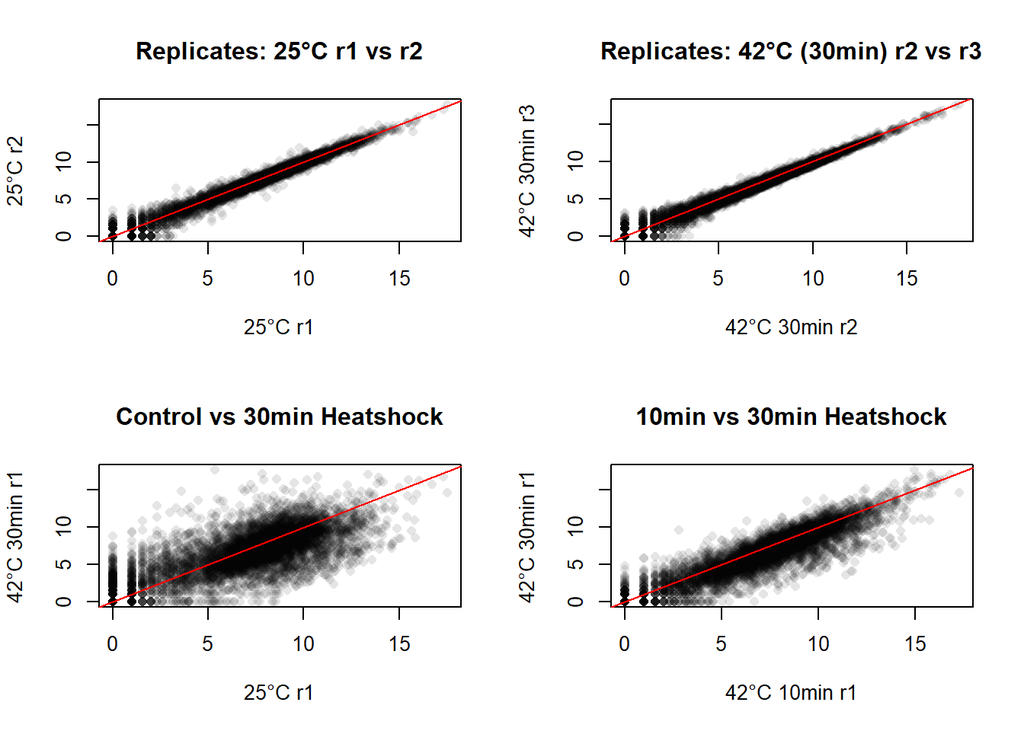

```r
par(mfrow  = c(2, 2))

#Control Replicates (25°C)
plot(log2(data[, 2] + 1), log2(data[, 3] +1),
     main = "Replicates: 25°C r1 vs r2",
     xlab = "25°C r1", ylab = "25°C r2",
     pch = 16, col = rgb(0,0,0,0.1))
abline(0, 1, col = "red")

#Heatshock Replicates (42°C, 30 min)
plot(log2(data[, 9] + 1), log2(data[, 10] + 1),
     main = "Replicates: 42°C (30min) r2 vs r3",
     xlab = "42°C 30min r2", ylab = "42°C 30min r3",
     pch = 16, col = rgb(0,0,0,0.1))
abline(0, 1, col = "red")

#Baseline vs. 30 min
plot(log2(data[, 2] + 1), log2(data[, 8] + 1),
     main = "Control vs 30min Heatshock",
     xlab = "25°C r1", ylab = "42°C 30min r1",
     pch = 16, col = rgb(0,0,0,0.1))
abline(0, 1, col = "red")

#10 min vs. 30 min
plot(log2(data[, 5] + 1), log2(data[, 8] + 1),
     main = "10min vs 30min Heatshock",
     xlab = "42°C 10min r1", ylab = "42°C 30min r1",
     pch = 16, col = rgb(0,0,0,0.1))
abline(0, 1, col = "red")
```

```r
par(mfrow = c(1, 1))
```

**Within the Same Condition (Top Row)**

consistency in data:

- Minimal Variance: In both the 25°C and 42°C (30min) plots, the dots align almost perfectly along the red y = x line.
- Technical Quality: This tight clustering indicates very low difference between replicates, meaning your technical noise is low and the data is reliable.
- Low-Count Dispersion: The only noticeable “spread” occurs at the very bottom left (low expression), which is normal in RNA-seq data.

**Between Different Conditions (Bottom Row)**

biological changes:

- Increased Variance: In the “Control vs 30min Heatshock” plot, the “cloud” of dots is significantly wider than in the replicate plots.
- Biological Response: The dots drifting away from the red line represent genes changing in response to heat. Dots above the line are genes increasing in expression at 30 minutes; dots below are decreasing.
- Temporal Shift: The “10min vs 30min” plot shows that while the samples are more similar to each other than to the control, there is still active “fine-tuning” occurring between these two heat-shock time points.

### Histogram raw vs. log2-transformed

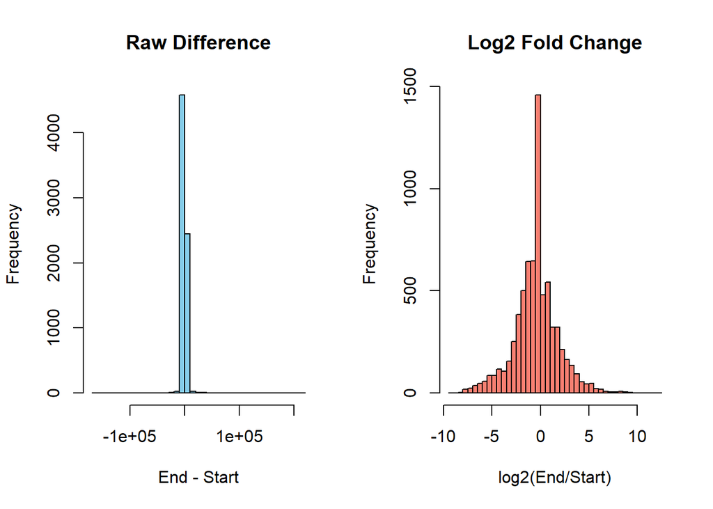

```r
# 1. assigning the samples
s_start <- data[, 2]  # 25_0_r1
s_end   <- data[, 8]  # 42_30_r1

# 2. Calculate Raw Difference
raw_diff <- s_end - s_start

# 3. Calculate Log2 Fold Change
# +1 to avoid dividing by zero or taking log of zero
log_fc <- log2((s_end + 1) / (s_start + 1))

# 4. Plotting next to each other
par(mfrow = c(1, 2))

hist(raw_diff, breaks = 50, main = "Raw Difference",
     xlab = "End - Start", col = "skyblue")

hist(log_fc, breaks = 50, main = "Log2 Fold Change",
     xlab = "log2(End/Start)", col = "salmon")
```

```r
par(mfrow = c(1, 1))
```

The raw distribution is not very useful because it’s dominated by “outliers” (the most highly expressed genes). You can’t see what’s happening to the thousands of medium- and low-expression genes.

### Expression levels

```r
# 1. Count how many zeros exist in each gene
row_zeros <- rowSums(data[, 2:10] == 0)

# 2. See how many genes fall into each "zero category"
# 0 means expressed in all samples, 9 means expressed in none
zero_table <- table(row_zeros)
print("Number of genes by zero-count frequency:")
```

```
## [1] "Number of genes by zero-count frequency:"
```

```r
print(zero_table)
```

```
## row_zeros
##    0    1    2    3    4    5    6    7    8    9
## 5678  178  129  118   75   61   63   79   81  664
```

```r
# 3. Compare average expression levels; Calculate the mean for every gene
row_means <- rowMeans(data[, 2:10])

# Mean for genes with no zeros vs genes with 1 or more zeros
mean_always_on <- mean(row_means[row_zeros == 0])
mean_sporadic  <- mean(row_means[row_zeros > 0])

cat("\nAvg count (Expressed in all 9):", round(mean_always_on, 2))
```

```
##
## Avg count (Expressed in all 9): 1035.93
```

```r
cat("\nAvg count (Expressed in < 9):", round(mean_sporadic, 2))
```

```
##
## Avg count (Expressed in < 9): 5.47
```